# Translating to AFNI 3dDeconvolve

Bradley R. Buchsbaum

2019-09-22

## Constructing an fMRI regression model and translating it for AFNI’s 3dDeconvolve

AFNI and other fMRI analysis packages have robust and efficient methods for estimating voxelwise regression models. Therefore, it may be beneficial to construct a regression model in R using **fmrireg** and translate it so that it can be executed using one of these packages. Here we provide a translation mechanism from an `fmri_model` object constructed with `fmrireg` to syntax and assocaited file required for execution using AFNI’s **3dDeconvolve** program.

## A Simple Model

Lets begin again with a simple fMRI design.

```r
cond <- c("face", "scene", "tool", "object")
NSTIM <- length(cond)*4

simple_design <- data.frame(stim=factor(sample(rep(cond, 4))),
                     ISI=sample(4:7, NSTIM, replace=TRUE),
                     run=rep(1, NSTIM),
                     trial=factor(1:NSTIM))
```

Now we add onset information, construct a `sampling_frame`, and finally an `event_model`:

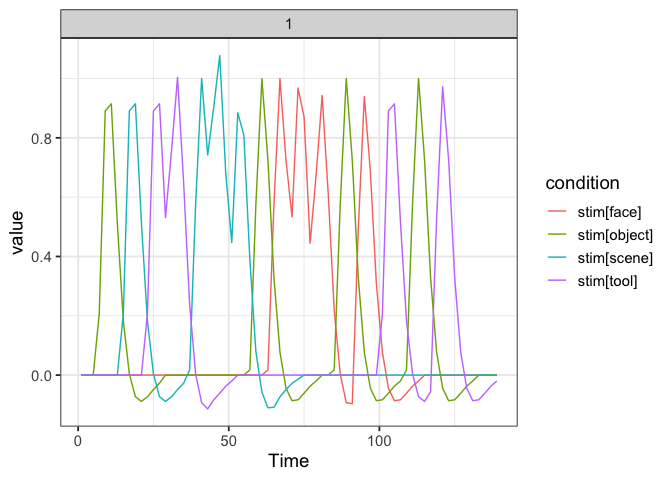

```r
simple_design$onset <- cumsum(simple_design$ISI+2) -2
sframe <- sampling_frame(blocklens=70, TR=2)
emodel <- event_model(onset ~ hrf(stim), data=simple_design, block = ~ run, sampling_frame=sframe)
plot(emodel)
```

We construct a `baseline_model` using a B-spline basis:

```r
bmodel <- baseline_model(basis="bs", degree=5, sframe=sframe)
print(bmodel)
```

```
## baseline_model
##    name:  baseline_bs_5
##    basis type:  bs
##    degree:  5
##    drift columns:  5
##    constant columns:  1
##    nuisance columns:  0
##    total columns:  6
##    design_matrix:
## # A tibble: 70 x 6
##    constant_1 base_bs1_block_1 base_bs2_block_1 base_bs3_block_1
##         <dbl>            <dbl>            <dbl>            <dbl>
##  1          1           0               0              0
##  2          1           0.0684          0.00201        0.0000296
##  3          1           0.129           0.00769        0.000230
##  4          1           0.182           0.0165         0.000752
##  5          1           0.228           0.0281         0.00173
##  6          1           0.268           0.0419         0.00327
##  7          1           0.302           0.0576         0.00548
##  8          1           0.331           0.0747         0.00843
##  9          1           0.354           0.0929         0.0122
## 10          1           0.373           0.112          0.0168
## # … with 60 more rows, and 2 more variables: base_bs4_block_1 <dbl>,
## #   base_bs5_block_1 <dbl>
```

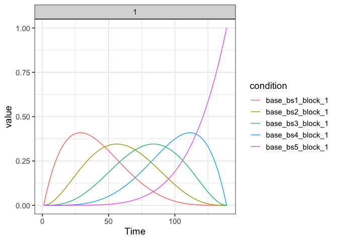

```r
plot(bmodel)
```

We construct an `fmri_model`:

```r
fmodel <- fmri_model(emodel, bmodel)
```

Now we need to specify the data that the model will be estimated on. Let us pretend that we have a single 4d NIfTI file called “scan01.nii” and a mask file called “mask.nii”.

```r
dset <- fmri_dataset(scans="scan01.nii",
                     mask="mask.nii",
                     TR=2,
                     run_length=70,
                     event_table=simple_design,
                     base_path=".")
```

We are now ready to construct an AFNI model specification:

```r
alm <- afni_lm(fmodel, dset)
```